# CS2_MD

Varun Gopal

2022-04-16

By Varun Gopal

Importing packages and dataset

```r
#Libraries
library(GGally)
library(tidyverse)
library(formattable)
library(plotly)
library(class)
library(caret)
library(e1071)
library(randomForest)
library(varImp)

#Import dataset
CS2=read.csv(file.choose(),header=T)
```

Investigating categorical variables

```r
#Make Attrition a factor
CS2$Attrition=as.factor(CS2$Attrition)

#Split Data into continuous vs categorical data
CS2cont=data.frame(rows=1:dim(CS2)[1]) #Build empty dfs
CS2cat=data.frame(rows=1:dim(CS2)[1])
#Fill in CS2cont with all 'int' types excluding those on scale of 1-5 or 1-10
for(i in 1:dim(CS2)[2]){
  if(class(CS2[,i])=='integer' & length(levels(as.factor(CS2[,i])))>5){
    CS2cont=cbind(CS2cont,CS2[i])
  } else{
    CS2cat=cbind(CS2cat,CS2[i])
  }
}

#Clean up columns and add attrition to CS2cont
CS2cont=CS2cont%>%select(!rows)
CS2cont$Attrition=CS2$Attrition
CS2cat=CS2cat%>%select(!rows)

#Loop to make all columns in CS2cat factors
for (i in 1:dim(CS2cat)[2]){
  CS2cat[,i]=as.factor(CS2cat[,i])
}

#INVESTIGATING CATEGORICAL VARIABLES

#Determine percent attrition based on business travel
BizTravel=as.data.frame(CS2cat%>%group_by(BusinessTravel)%>%summarize(total=n()))
BizTravelAttr=as.data.frame(CS2cat%>%filter(Attrition=='Yes')%>%group_by(BusinessTravel)%>%summarize(num_yes=n()))
BizTravel=merge(BizTravel,BizTravelAttr,by='BusinessTravel')
BizTravel$Percent_Attrition=BizTravel$num_yes/BizTravel$total
colnames(BizTravel)[c(1,4)]=c('Frequency of Business Travel','Percent Attrition')
formattable(BizTravel[,c(1,4)])
```

| Frequency of Business Travel | Percent Attrition |
| --- | --- |
| Non-Travel | 0.1170213 |
| Travel_Frequently | 0.2215190 |
| Travel_Rarely | 0.1521036 |

```r
#Determine percent attrition based on department
Dep=as.data.frame(CS2cat%>%group_by(Department)%>%summarize(total=n()))
DepAttr=as.data.frame(CS2cat%>%filter(Attrition=='Yes')%>%group_by(Department)%>%summarize(num_yes=n()))
Dep=merge(Dep,DepAttr,by='Department')
Dep$Percent_Attrition=Dep$num_yes/Dep$total
colnames(Dep)[c(1,4)]=c('Department','Percent Attrition')
formattable(Dep[,c(1,4)])
```

| Department | Percent Attrition |
| --- | --- |
| Human Resources | 0.1714286 |
| Research & Development | 0.1334520 |
| Sales | 0.2161172 |

```r
#Determine percent attrition based on years of education
Edu=as.data.frame(CS2cat%>%group_by(Education)%>%summarize(total=n()))
EduAttr=as.data.frame(CS2cat%>%filter(Attrition=='Yes')%>%group_by(Education)%>%summarize(num_yes=n()))
Edu=merge(Edu,EduAttr,by='Education')
Edu$Percent_Attrition=Edu$num_yes/Edu$total
colnames(Edu)[c(1,4)]=c('Years Studying','Percent Attrition')
formattable(Edu[,c(1,4)])
```

| Years Studying | Percent Attrition |
| --- | --- |
| 1 | 0.1836735 |
| 2 | 0.1758242 |
| 3 | 0.1697531 |
| 4 | 0.1333333 |
| 5 | 0.1153846 |

```r
#Determine percent attrition based on education field
EduF=as.data.frame(CS2cat%>%group_by(EducationField)%>%summarize(total=n()))
EduFAttr=as.data.frame(CS2cat%>%filter(Attrition=='Yes')%>%group_by(EducationField)%>%summarize(num_yes=n()))
EduF=merge(EduF,EduFAttr,by='EducationField')
EduF$Percent_Attrition=EduF$num_yes/EduF$total
colnames(EduF)[c(1,4)]=c('Field of Study','Percent Attrition')
formattable(EduF[,c(1,4)])
```

| Field of Study | Percent Attrition |
| --- | --- |
| Human Resources | 0.2666667 |
| Life Sciences | 0.1480447 |
| Marketing | 0.2000000 |
| Medical | 0.1370370 |
| Other | 0.1730769 |
| Technical Degree | 0.2266667 |

```r
#Determine percent attrition based on Environmental Satisfaction
EnvSat=as.data.frame(CS2cat%>%group_by(EnvironmentSatisfaction)%>%summarize(total=n()))
EnvSatAttr=as.data.frame(CS2cat%>%filter(Attrition=='Yes')%>%group_by(EnvironmentSatisfaction)%>%summarize(num_yes=n()))
EnvSat=merge(EnvSat,EnvSatAttr,by='EnvironmentSatisfaction')
EnvSat$Percent_Attrition=EnvSat$num_yes/EnvSat$total
colnames(EnvSat)[c(1,4)]=c('Environmental Satisfaction','Percent Attrition')
formattable(EnvSat[,c(1,4)])
```

| Environmental Satisfaction | Percent Attrition |
| --- | --- |
| 1 | 0.2441860 |
| 2 | 0.1348315 |
| 3 | 0.1356589 |
| 4 | 0.1488550 |

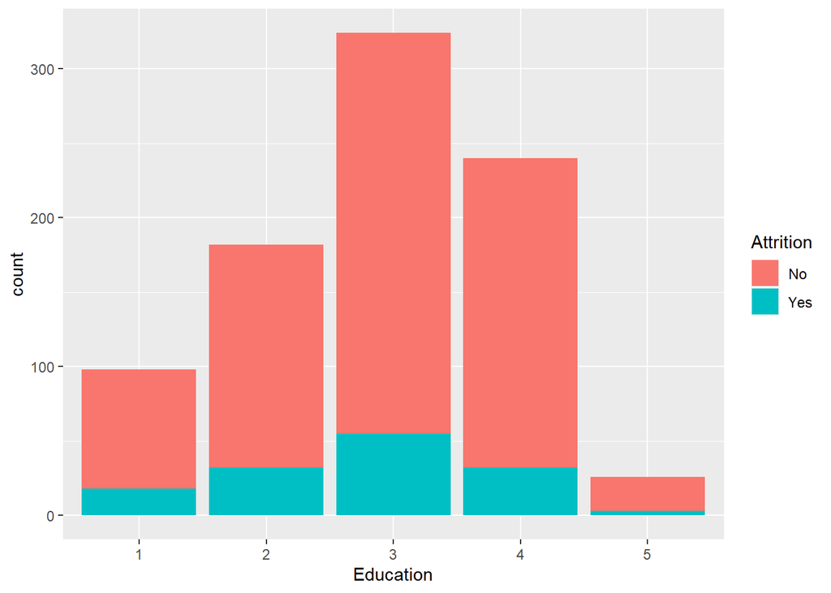

```r
CS2cat%>%ggplot(aes(x=Education,fill=Attrition))+
  geom_bar()
```

```r
#Determine percent attrition based on Gender
Gender=as.data.frame(CS2cat%>%group_by(Gender)%>%summarize(total=n()))
GenderAttr=as.data.frame(CS2cat%>%filter(Attrition=='Yes')%>%group_by(Gender)%>%summarize(num_yes=n()))
Gender=merge(Gender,GenderAttr,by='Gender')
Gender$Percent_Attrition=Gender$num_yes/Gender$total
colnames(Gender)[c(1,4)]=c('Gender','Percent Attrition')
formattable(Gender[,c(1,4)])
```

| Gender | Percent Attrition |
| --- | --- |
| Female | 0.1497175 |
| Male | 0.1686047 |

```r
#Determine percent attrition based on Job Involvement
JobInv=as.data.frame(CS2cat%>%group_by(JobInvolvement)%>%summarize(total=n()))
JobInvAttr=as.data.frame(CS2cat%>%filter(Attrition=='Yes')%>%group_by(JobInvolvement)%>%summarize(num_yes=n()))
JobInv=merge(JobInv,JobInvAttr,by='JobInvolvement')
JobInv$Percent_Attrition=JobInv$num_yes/JobInv$total
colnames(JobInv)[c(1,4)]=c('Job Involvement','Percent Attrition')
formattable(JobInv[,c(1,4)])
```

| Job Involvement | Percent Attrition |
| --- | --- |
| 1 | 0.46808511 |
| 2 | 0.19298246 |
| 3 | 0.13035019 |
| 4 | 0.08641975 |

```r
#Determine percent attrition based on Job Level
JobLvl=as.data.frame(CS2cat%>%group_by(JobLevel)%>%summarize(total=n()))
JobLvlAttr=as.data.frame(CS2cat%>%filter(Attrition=='Yes')%>%group_by(JobLevel)%>%summarize(num_yes=n()))
JobLvl=merge(JobLvl,JobLvlAttr,by='JobLevel')
JobLvl$Percent_Attrition=JobLvl$num_yes/JobLvl$total
colnames(JobLvl)[c(1,4)]=c('Job Level','Percent Attrition')
formattable(JobLvl[,c(1,4)])
```

| Job Level | Percent Attrition |
| --- | --- |
| 1 | 0.26139818 |
| 2 | 0.09615385 |
| 3 | 0.12878788 |
| 4 | 0.05000000 |
| 5 | 0.10810811 |

```r
#Determine percent attrition based on Job Role
Role=as.data.frame(CS2cat%>%group_by(JobRole)%>%summarize(total=n()))
RoleAttr=as.data.frame(CS2cat%>%filter(Attrition=='Yes')%>%group_by(JobRole)%>%summarize(num_yes=n()))
Role=merge(Role,RoleAttr,by='JobRole')
Role$Percent_Attrition=Role$num_yes/Role$total
colnames(Role)[c(1,4)]=c('Job Role','Percent Attrition')
formattable(Role[,c(1,4)])
```

| Job Role | Percent Attrition |
| --- | --- |
| Healthcare Representative | 0.10526316 |
| Human Resources | 0.22222222 |
| Laboratory Technician | 0.19607843 |
| Manager | 0.07843137 |
| Manufacturing Director | 0.02298851 |
| Research Director | 0.01960784 |
| Research Scientist | 0.18604651 |
| Sales Executive | 0.16500000 |
| Sales Representative | 0.45283019 |

```r
#Determine percent attrition based on Job Satisfaction
JobSat=as.data.frame(CS2cat%>%group_by(JobSatisfaction)%>%summarize(total=n()))
JobSatAttr=as.data.frame(CS2cat%>%filter(Attrition=='Yes')%>%group_by(JobSatisfaction)%>%summarize(num_yes=n()))
JobSat=merge(JobSat,JobSatAttr,by='JobSatisfaction')
JobSat$Percent_Attrition=JobSat$num_yes/JobSat$total
colnames(JobSat)[c(1,4)]=c('Job Satisfaction','Percent Attrition')
formattable(JobSat[,c(1,4)])
```

| Job Satisfaction | Percent Attrition |
| --- | --- |
| 1 | 0.2122905 |
| 2 | 0.1867470 |
| 3 | 0.1692913 |
| 4 | 0.1033210 |

```r
#Determine percent attrition based on Marital Status
Married=as.data.frame(CS2cat%>%group_by(MaritalStatus)%>%summarize(total=n()))
MarriedAttr=as.data.frame(CS2cat%>%filter(Attrition=='Yes')%>%group_by(MaritalStatus)%>%summarize(num_yes=n()))
Married=merge(Married,MarriedAttr,by='MaritalStatus')
Married$Percent_Attrition=Married$num_yes/Married$total
colnames(Married)[c(1,4)]=c('Marital Status','Percent Attrition')
formattable(Married[,c(1,4)])
```

| Marital Status | Percent Attrition |
| --- | --- |
| Divorced | 0.06282723 |
| Married | 0.14146341 |
| Single | 0.26022305 |

```r
#Determine percent attrition based on Overtime
OT=as.data.frame(CS2cat%>%group_by(OverTime)%>%summarize(total=n()))
OTAttr=as.data.frame(CS2cat%>%filter(Attrition=='Yes')%>%group_by(OverTime)%>%summarize(num_yes=n()))
OT=merge(OT,OTAttr,by='OverTime')
OT$Percent_Attrition=OT$num_yes/OT$total
colnames(OT)[c(1,4)]=c('Overtime','Percent Attrition')
formattable(OT[,c(1,4)])
```

| Overtime | Percent Attrition |
| --- | --- |
| No | 0.09708738 |
| Yes | 0.31746032 |

```r
#Determine percent attrition based on Performance Rating
PR=as.data.frame(CS2cat%>%group_by(PerformanceRating)%>%summarize(total=n()))
PRAttr=as.data.frame(CS2cat%>%filter(Attrition=='Yes')%>%group_by(PerformanceRating)%>%summarize(num_yes=n()))
PR=merge(PR,PRAttr,by='PerformanceRating')
PR$Percent_Attrition=PR$num_yes/PR$total
colnames(PR)[c(1,4)]=c('Performance Rating','Percent Attrition')
formattable(PR[,c(1,4)])
```

| Performance Rating | Percent Attrition |
| --- | --- |
| 3 | 0.1585366 |
| 4 | 0.1742424 |

```r
#Determine percent attrition based on Relationship Satisfaction
RelSat=as.data.frame(CS2cat%>%group_by(RelationshipSatisfaction)%>%summarize(total=n()))
RelSatAttr=as.data.frame(CS2cat%>%filter(Attrition=='Yes')%>%group_by(RelationshipSatisfaction)%>%summarize(num_yes=n()))
RelSat=merge(RelSat,RelSatAttr,by='RelationshipSatisfaction')
RelSat$Percent_Attrition=RelSat$num_yes/RelSat$total
colnames(RelSat)[c(1,4)]=c('Relationship Satisfaction','Percent Attrition')
formattable(RelSat[,c(1,4)])
```

| Relationship Satisfaction | Percent Attrition |
| --- | --- |
| 1 | 0.2011494 |
| 2 | 0.1578947 |
| 3 | 0.1379310 |
| 4 | 0.1590909 |

```r
#Determine percent attrition based on Stock Option Level
StockLvl=as.data.frame(CS2cat%>%group_by(StockOptionLevel)%>%summarize(total=n()))
StockLvlAttr=as.data.frame(CS2cat%>%filter(Attrition=='Yes')%>%group_by(StockOptionLevel)%>%summarize(num_yes=n()))
StockLvl=merge(StockLvl,StockLvlAttr,by='StockOptionLevel')
StockLvl$Percent_Attrition=StockLvl$num_yes/StockLvl$total
colnames(StockLvl)[c(1,4)]=c('Stock Option Level','Percent Attrition')
formattable(StockLvl[,c(1,4)])
```

| Stock Option Level | Percent Attrition |
| --- | --- |
| 0 | 0.25857520 |
| 1 | 0.07605634 |
| 2 | 0.03703704 |
| 3 | 0.21818182 |

```r
#Determine percent attrition based on Work Life Balance
WLB=as.data.frame(CS2cat%>%group_by(WorkLifeBalance)%>%summarize(total=n()))
WLBAttr=as.data.frame(CS2cat%>%filter(Attrition=='Yes')%>%group_by(WorkLifeBalance)%>%summarize(num_yes=n()))
WLB=merge(WLB,WLBAttr,by='WorkLifeBalance')
WLB$Percent_Attrition=WLB$num_yes/WLB$total
colnames(WLB)[c(1,4)]=c('Work Life Balance','Percent Attrition')
formattable(WLB[,c(1,4)])
```

| Work Life Balance | Percent Attrition |
| --- | --- |
| 1 | 0.3541667 |
| 2 | 0.1562500 |
| 3 | 0.1503759 |
| 4 | 0.1326531 |

Investigating continuous variables

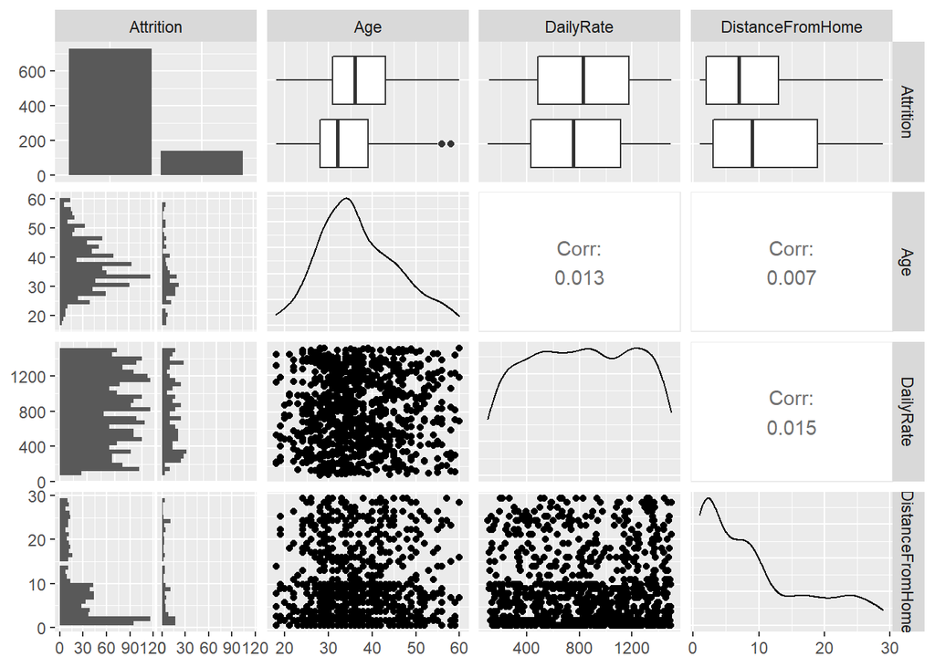

```r
#INVESTIGATE CONTINUOUS VARIABLES

#Comparing attrition with age, dailyrate, and distancefromhome
CS2cont[,c(17,2,3,4)]%>%ggpairs()
```

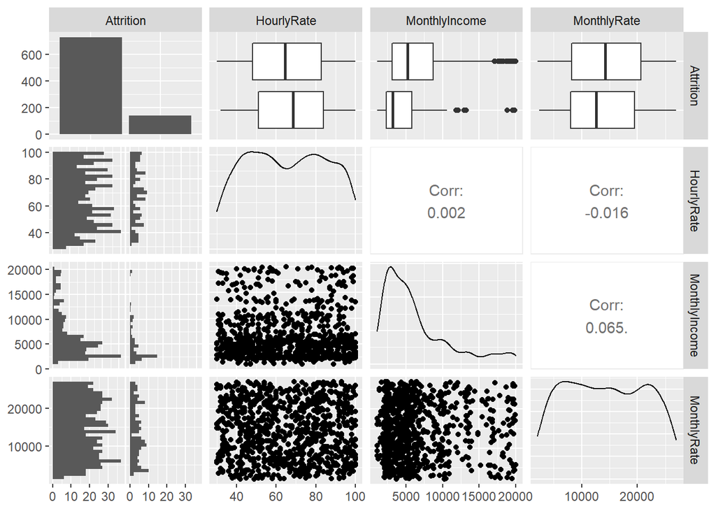

```r
#Comparing attrition with hourlyrate, monthlyincome, and monthlyrate
CS2cont[,c(17,6,7,8)]%>%ggpairs()
```

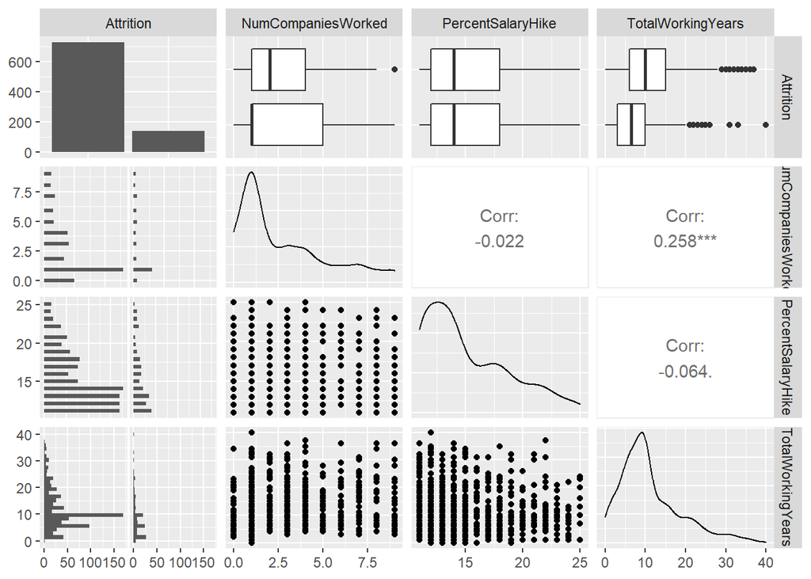

```r
#Comparing attrition with numcompaniesworked, percentsalaryhike, and totalworkingyears
CS2cont[,c(17,9,10,11)]%>%ggpairs()
```

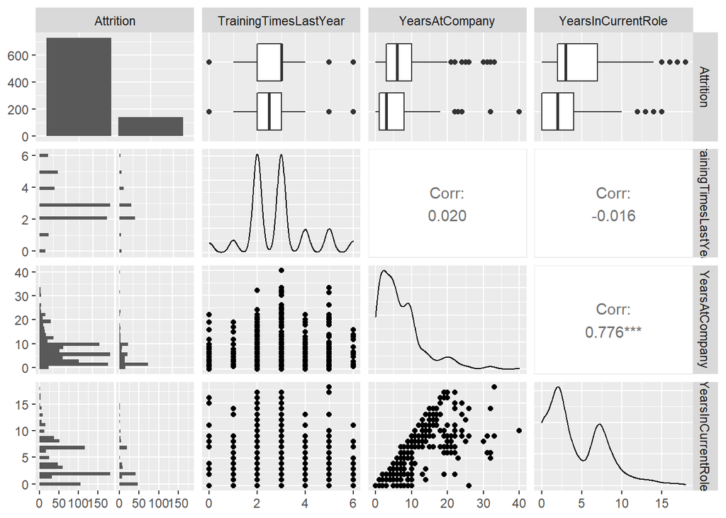

```r
#Comparing attrition with trainingtimeslastyear, yearsatcompany, and yearsincurrentrole
CS2cont[,c(17,12,13,14)]%>%ggpairs()
```

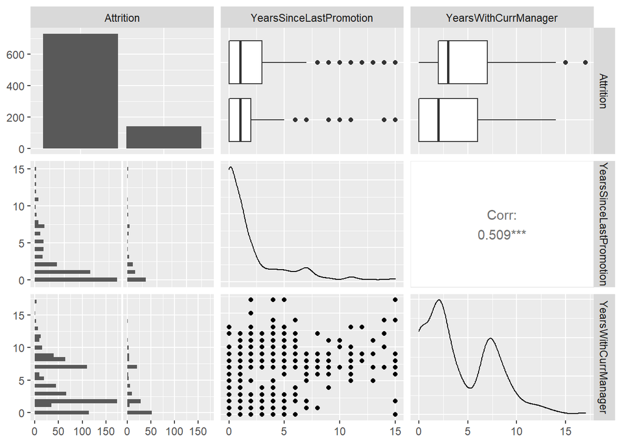

```r
#Comparing attrition with yearssincelastpromotion and yearswithcurrmanager
CS2cont[,c(17,15,16)]%>%ggpairs()
```

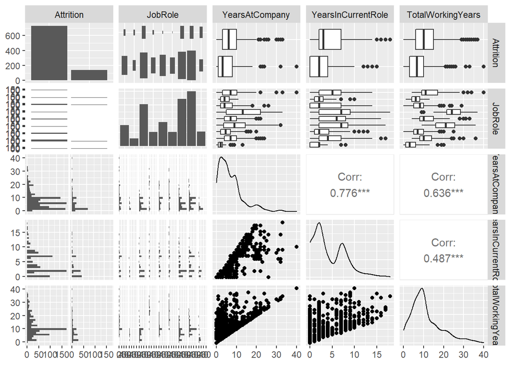

```r
CS2%>%select(Attrition,JobRole,YearsAtCompany,YearsInCurrentRole,TotalWorkingYears)%>%ggpairs()
```

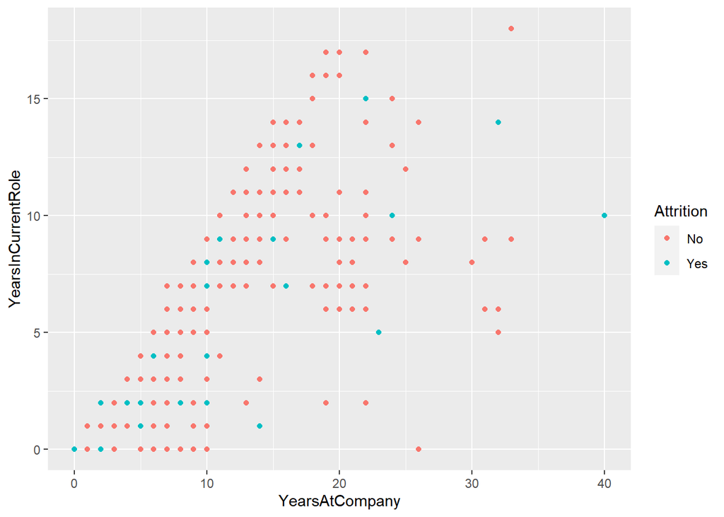

```r
CS2%>%ggplot(aes(x=YearsAtCompany,y=YearsInCurrentRole,col=Attrition))+
  geom_point()
```

Testing Models

```r
#TESTING MODELS

#Cleaning up CS2
CS2clean=CS2%>%select(!(ID|EmployeeCount|EmployeeNumber|Over18|StandardHours))

#Create Training and Test Split
seednum=sample(1:100000,1)#seed number
set.seed(seednum)#Random seed
TrainInd=sample(1:dim(CS2)[1],round(0.7*dim(CS2)[1]))#Sample of 70% of total values
AttrTrain=CS2clean[TrainInd,]#Random 70% of CS2 put into training set
AttrTest=CS2clean[-TrainInd,]#Random 30% of CS2 put into test set

SpecMatrix=matrix(nrow=1000,ncol=2)
colnames(SpecMatrix)=c('Seed Number','Specificity')

#Loop to tune seed
for (i in 1:dim(SpecMatrix)[1]){
  set.seed(i)
  #Split CS2 into sets w/ Attrition=='Yes' and Attrition=='No'
  CS2Yes=CS2clean%>%filter(Attrition=='Yes')
  CS2No=CS2clean%>%filter(Attrition=='No')
  IndexYes=sample(1:dim(CS2Yes)[1],round(0.7*dim(CS2Yes)[1]))
  IndexNo=sample(1:dim(CS2No)[1],round(0.7*dim(CS2No)[1]))

  #Training/Test Splits Yes and No
  TrainYes=CS2Yes[IndexYes,]
  TestYes=CS2Yes[-IndexYes,]
  TrainNo=CS2No[IndexNo,]
  TestNo=CS2No[-IndexNo,]

  #Merge Training and Test Splits
  AttrTrain=rbind(TrainYes,TrainNo)
  AttrTest=rbind(TestYes,TestNo)

  #Run Machine Learning Models
  model=naiveBayes(Attrition~.,data=AttrTrain)
  AttrClass=predict(model,AttrTest)

  CM=confusionMatrix(table(AttrClass,AttrTest$Attrition))
  SpecMatrix[i,1]=i
  SpecMatrix[i,2]=CM$byClass['Specificity']
}
#Find the best seed out of 1000
SpecMatrix=as.data.frame(SpecMatrix)
SpecMatrix%>%filter(Specificity==max(Specificity))
```

```
##   Seed Number Specificity
## 1          58   0.7857143
```

```r
#Stratified Training/Test Split
seednum=sample(1:100000,1)#seed number
hiseed=58 #Tuned seed
set.seed(hiseed)#Random seed

#Split CS2 into sets w/ Attrition=='Yes' and Attrition=='No'
CS2Yes=CS2clean%>%filter(Attrition=='Yes')
CS2No=CS2clean%>%filter(Attrition=='No')
IndexYes=sample(1:dim(CS2Yes)[1],round(0.7*dim(CS2Yes)[1]))
IndexNo=sample(1:dim(CS2No)[1],round(0.7*dim(CS2No)[1]))

#Training/Test Splits Yes and No
TrainYes=CS2Yes[IndexYes,]
TestYes=CS2Yes[-IndexYes,]
TrainNo=CS2No[IndexNo,]
TestNo=CS2No[-IndexNo,]

#Merge Training and Test Splits
AttrTrain=rbind(TrainYes,TrainNo)
AttrTest=rbind(TestYes,TestNo)

#Run Machine Learning Models
NBmodel=naiveBayes(Attrition~.,data=AttrTrain)
AttrClassNB=predict(NBmodel,AttrTest)
NBCM=confusionMatrix(table(AttrClassNB,AttrTest$Attrition))

RFmodel=randomForest(Attrition~.,data=AttrTrain,ntree=435)
AttrClassRF=predict(RFmodel,AttrTest)
RFCM=confusionMatrix(table(AttrClassRF,AttrTest$Attrition))

#Tuning ntree
RFSpec=data.frame(ntree=100:500,Specificity=NA)

for (i in 100:500){
  RFmodel=randomForest(Attrition~.,data=AttrTrain,importance=T,ntree=i)
  AttrClassRF=predict(RFmodel,AttrTest)
  RFCM=confusionMatrix(table(AttrClassRF,AttrTest$Attrition))
  RFSpec[(i-99),2]=RFCM$byClass['Specificity']
}
dim(RFSpec)
```

```
## [1] 401   2
```

```r
RFSpec%>%filter(Specificity==max(Specificity))
```

```
##   ntree Specificity
## 1   146   0.1666667
## 2   191   0.1666667
```

```r
head(RFSpec)
```

```
##   ntree Specificity
## 1   100  0.07142857
## 2   101  0.07142857
## 3   102  0.07142857
## 4   103  0.09523810
## 5   104  0.11904762
## 6   105  0.09523810
```

Attempt at permutation feature importance. I tried to code in feature shuffling, and I used balanced accuracy to measure impact on the model. However, I acknowledge that I may have made quite a few mistakes in both my code and my grasp of the concept. Regardless, this is my best attempt

```r
#After multiple attempts, naive Bayes was a better model than random forest


#permutation feature importance Naive Bayes
CS2perm=CS2clean%>%select(!Attrition)
CS2perm$Attrition=CS2clean$Attrition
AccDiff=matrix(nrow=30,ncol=2)

for (i in 1:(dim(CS2perm)[2]-1)){
  #seed for split
  set.seed(58)
  #Stratified Sample
  #70/30 train/test split based on Attrition='Yes'
  PermYes=CS2perm%>%filter(Attrition=='Yes')
  IndYes=sample(1:dim(PermYes)[1],round(0.7*dim(PermYes)[1]))
  PermYesTrain=PermYes[IndYes,]
  PermYesTest=PermYes[-IndYes,]

  #70/30 train/test split based on Attrition='No'
  PermNo=CS2perm%>%filter(Attrition=='No')
  IndNo=sample(1:dim(PermNo)[1],round(0.7*dim(PermNo)[1]))
  PermNoTrain=PermNo[IndNo,]
  PermNoTest=PermNo[-IndNo,]

  #Merge train/test
  PermTrain=rbind(PermYesTrain,PermNoTrain)
  PermTest=rbind(PermYesTest,PermNoTest)

  #Naive Bayes
  unshuffled=naiveBayes(Attrition~.,data=PermTrain)
  unshuffledClass=predict(unshuffled,PermTest)
  UCM=confusionMatrix(table(unshuffledClass,PermTest$Attrition))

  #Seed to shuffle
  seednum=sample(1:(dim(AccDiff)[1])^6,1)#Change this on every iteration for a different shuffle
  set.seed(seednum)
  #Shuffle Test Column
  PermTrain[,i]=sample(PermTrain[,i])

  set.seed(58)
  #Naive Bayes
  shuffled=naiveBayes(Attrition~.,data=PermTrain)
  shuffledClass=predict(shuffled,PermTest)
  SCM=confusionMatrix(table(shuffledClass,PermTest$Attrition))

  AccDiff[i,2]=UCM$byClass['Balanced Accuracy']-SCM$byClass['Balanced Accuracy']
  AccDiff[i,1]=colnames(CS2perm)[i]
}
AccDiff=as.data.frame(AccDiff)
colnames(AccDiff)=c('Shuffled_Feature','BADiff')
AccDiff%>%arrange(desc(BADiff))
```

```
##            Shuffled_Feature               BADiff
## 1                  OverTime   0.0993150684931507
## 2             MaritalStatus   0.0499021526418787
## 3   EnvironmentSatisfaction   0.0458251793868232
## 4                 DailyRate   0.0238095238095237
## 5           WorkLifeBalance   0.0215264187866928
## 6                       Age    0.016470971950424
## 7  RelationshipSatisfaction    0.014187866927593
## 8        YearsInCurrentRole   0.0123939986953685
## 9            JobInvolvement   0.0119047619047619
## 10                 JobLevel   0.0106001304631442
## 11                  JobRole   0.0106001304631442
## 12            MonthlyIncome   0.0106001304631442
## 13          JobSatisfaction  0.00962165688193095
## 14         StockOptionLevel  0.00962165688193095
```

[output cut: 16 more lines]

```r
seednum
```

```
## [1] 415541709
```

Examining Overtime

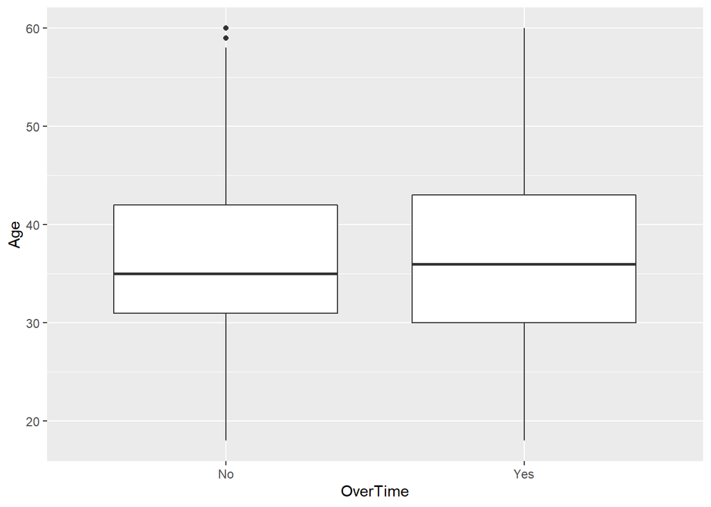

```r
#Examine Overtime

#Compare Overtime to Age
CS2%>%ggplot(aes(x=OverTime,y=Age))+
  geom_boxplot()
```

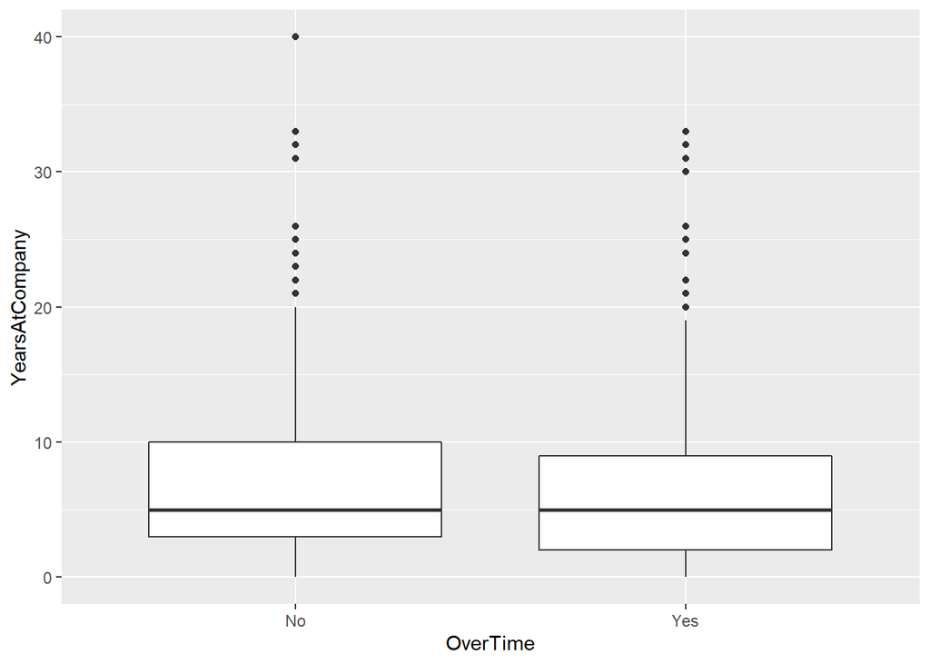

```r
#Compare Overtime to years in company
CS2%>%ggplot(aes(x=OverTime,y=YearsAtCompany))+
  geom_boxplot()
```

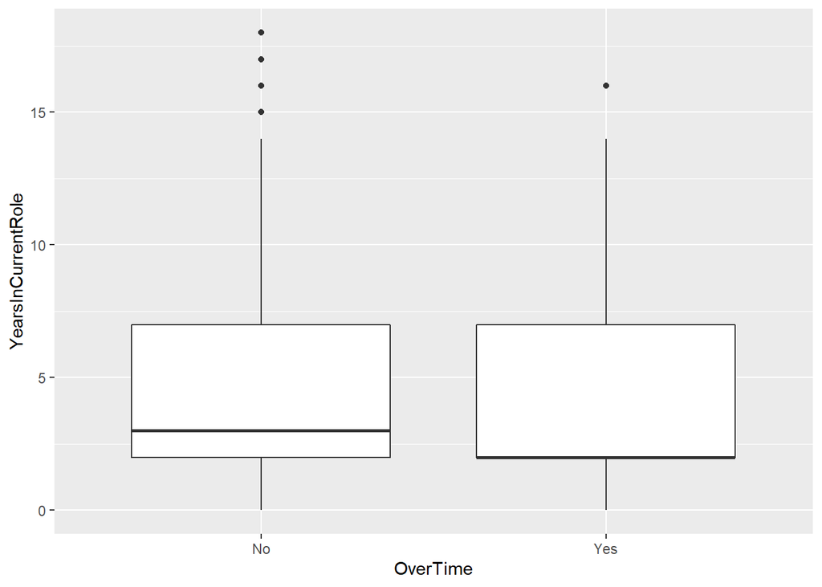

```r
#Compare Overtime to years in current role
CS2%>%ggplot(aes(x=OverTime,y=YearsInCurrentRole))+
  geom_boxplot()
```

```r
#Compare percent overtime to job role
RoleOT1=CS2%>%group_by(JobRole)%>%summarize(total=n())
RoleOT2=CS2%>%filter(OverTime=='Yes')%>%group_by(JobRole)%>%summarize(num_yes=n())
RoleOT=merge(RoleOT1,RoleOT2,by='JobRole')
RoleOT$PercentOT=RoleOT$num_yes/RoleOT$total
colnames(RoleOT)[c(1,4)]=c('Job Role','Percent Overtime')
formattable(RoleOT[,c(1,4)])
```

| Job Role | Percent Overtime |
| --- | --- |
| Healthcare Representative | 0.2894737 |
| Human Resources | 0.2222222 |
| Laboratory Technician | 0.2156863 |
| Manager | 0.1960784 |
| Manufacturing Director | 0.2643678 |
| Research Director | 0.3137255 |
| Research Scientist | 0.3779070 |
| Sales Executive | 0.2950000 |
| Sales Representative | 0.3396226 |

```r
Role
```

```
##                    Job Role total num_yes Percent Attrition
## 1 Healthcare Representative    76       8        0.10526316
## 2           Human Resources    27       6        0.22222222
## 3     Laboratory Technician   153      30        0.19607843
## 4                   Manager    51       4        0.07843137
## 5    Manufacturing Director    87       2        0.02298851
## 6         Research Director    51       1        0.01960784
## 7        Research Scientist   172      32        0.18604651
## 8           Sales Executive   200      33        0.16500000
## 9      Sales Representative    53      24        0.45283019
```

```r
#Compare percent overtime to department
DepOT1=CS2%>%group_by(Department)%>%summarize(total=n())
DepOT2=CS2%>%filter(OverTime=='Yes')%>%group_by(Department)%>%summarize(num_yes=n())
DepOT=merge(DepOT1,DepOT2,by='Department')
DepOT$PercentOT=DepOT$num_yes/DepOT$total
colnames(DepOT)[c(1,4)]=c('Department','Percent Overtime')
formattable(DepOT[,c(1,4)])
```

| Department | Percent Overtime |
| --- | --- |
| Human Resources | 0.2285714 |
| Research & Development | 0.2918149 |
| Sales | 0.2930403 |

```r
CS2%>%group_by(OverTime)%>%summarize(count=n())
```

```
## # A tibble: 2 x 2
##   OverTime count
##   <chr>    <int>
## 1 No         618
## 2 Yes        252
```

Examining Job Role

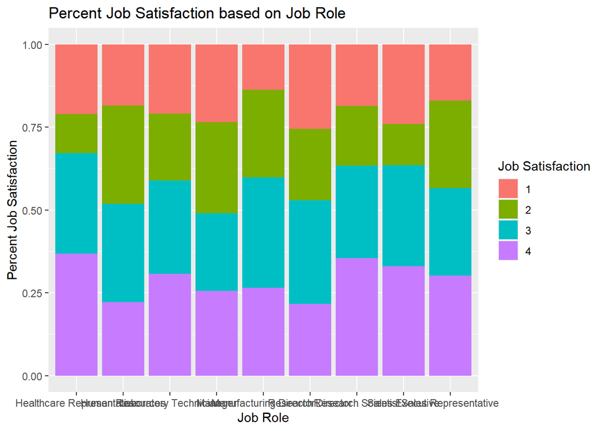

```r
#job role and satisfaction
CS2cat%>%ggplot(aes(x=JobRole,fill=JobSatisfaction))+
  geom_bar(position='fill')+
  labs(title='Percent Job Satisfaction based on Job Role',
       x='Job Role',
       y='Percent Job Satisfaction')+
  scale_fill_discrete(name='Job Satisfaction')
```

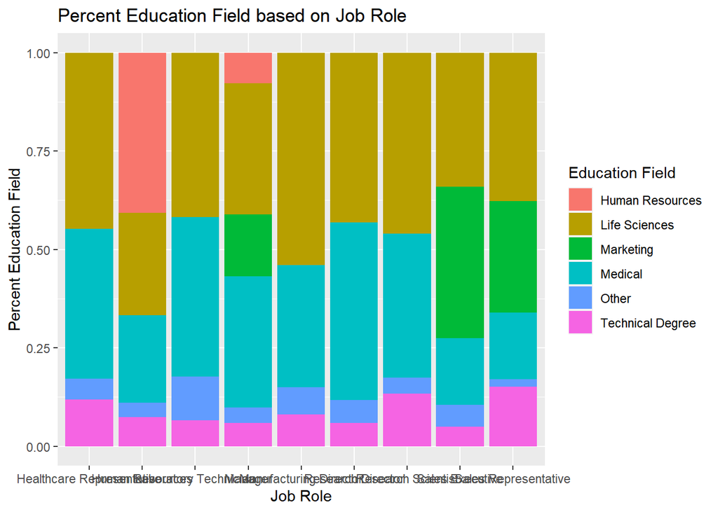

```r
#job role and education field
CS2cat%>%ggplot(aes(x=JobRole,fill=EducationField))+
  geom_bar(position='fill')+
  labs(title='Percent Education Field based on Job Role',
       x='Job Role',
       y='Percent Education Field')+
  scale_fill_discrete(name='Education Field')
```

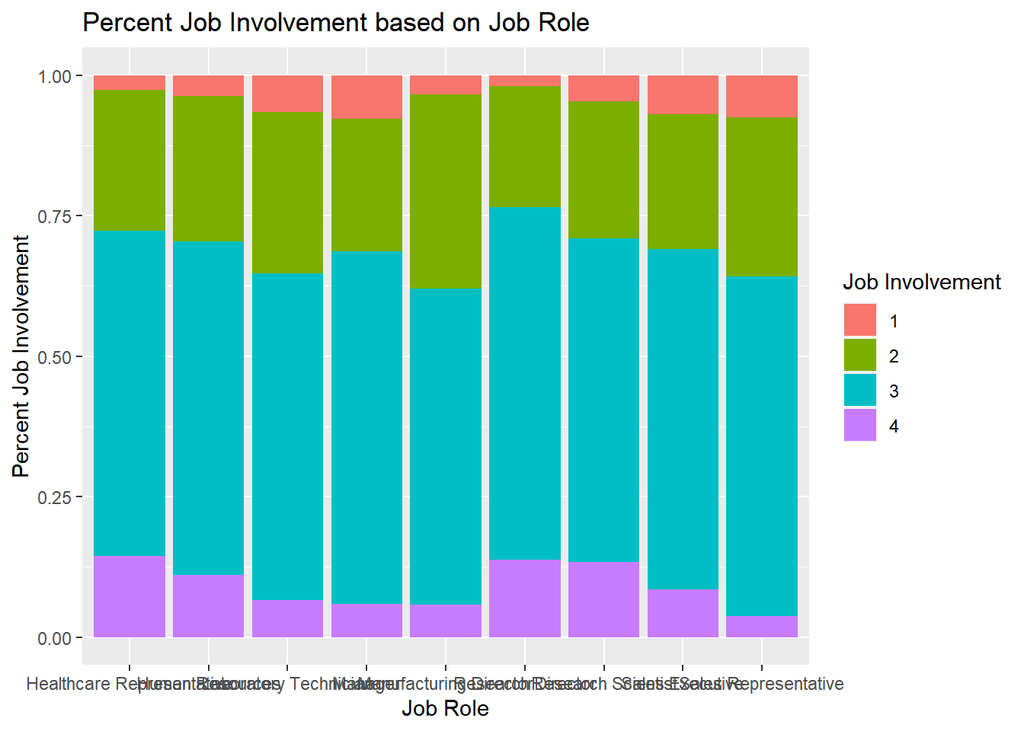

```r
#job role and job involvement
CS2cat%>%ggplot(aes(x=JobRole,fill=JobInvolvement))+
  geom_bar(position='fill')+
  labs(title='Percent Job Involvement based on Job Role',
       x='Job Role',
       y='Percent Job Involvement')+
  scale_fill_discrete(name='Job Involvement')
```

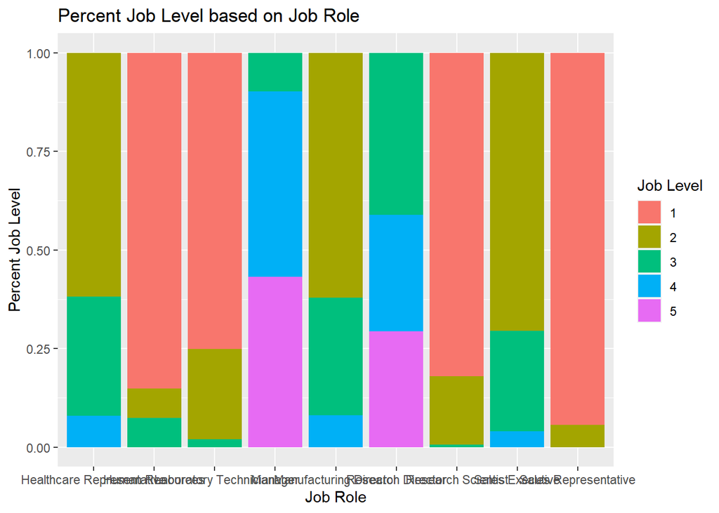

```r
#job role and job level
CS2cat%>%ggplot(aes(x=JobRole,fill=JobLevel))+
  geom_bar(position='fill')+
  labs(title='Percent Job Level based on Job Role',
       x='Job Role',
       y='Percent Job Level')+
  scale_fill_discrete(name='Job Level')
```

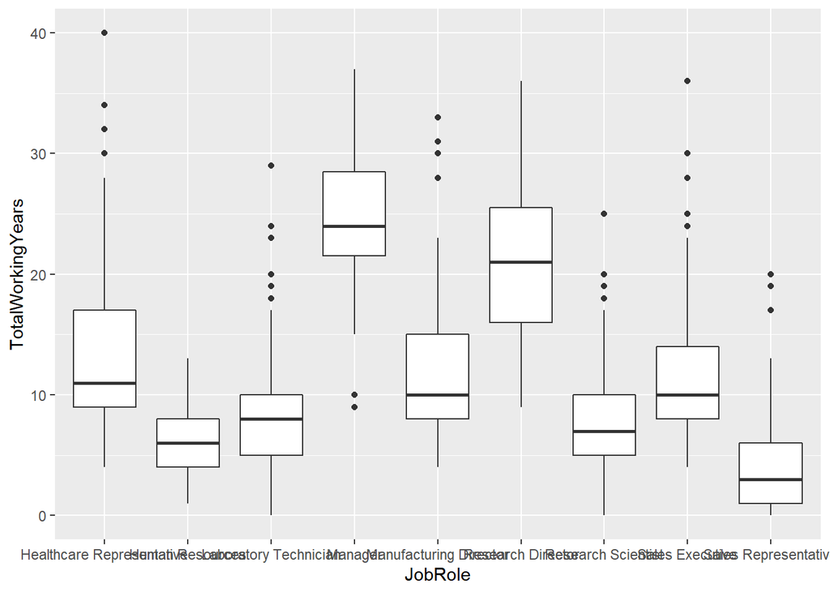

```r
#job role and years working
CS2%>%ggplot(aes(x=JobRole,y=TotalWorkingYears))+
  geom_boxplot()
```

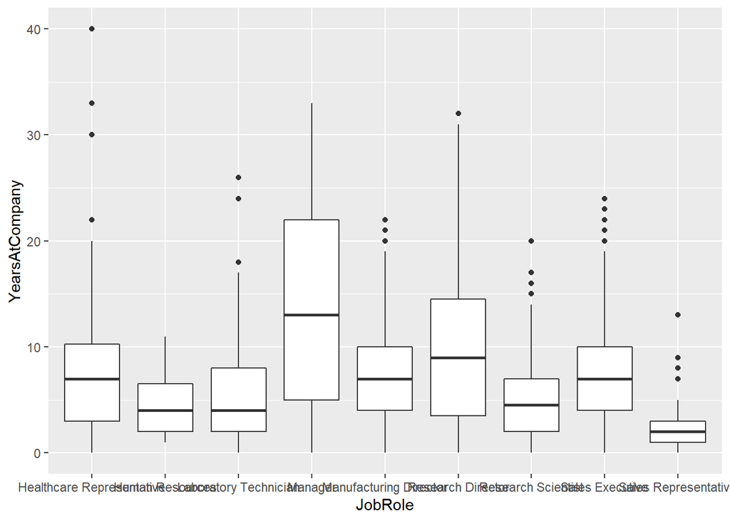

```r
#job role and years at company
CS2%>%ggplot(aes(x=JobRole,y=YearsAtCompany))+
  geom_boxplot()
```

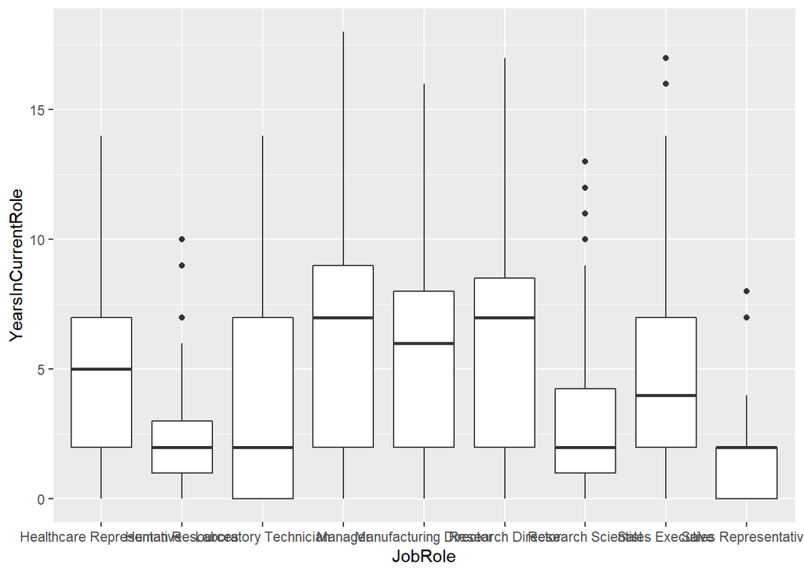

```r
#job role and years in current role
CS2%>%ggplot(aes(x=JobRole,y=YearsInCurrentRole))+
  geom_boxplot()
```

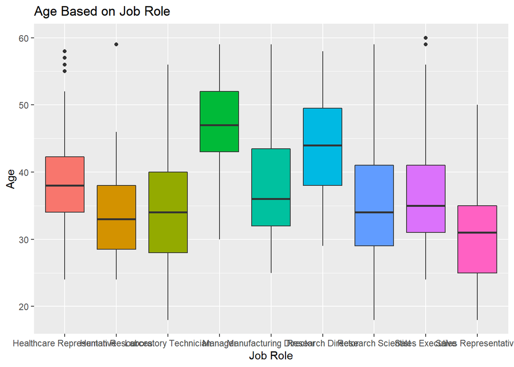

```r
#job role and age
CS2%>%ggplot(aes(x=JobRole,y=Age,fill=JobRole))+
  geom_boxplot()+
  labs(title='Age Based on Job Role',
       x='Job Role')+
  theme(legend.position='none')
```

Re-Examining attrition

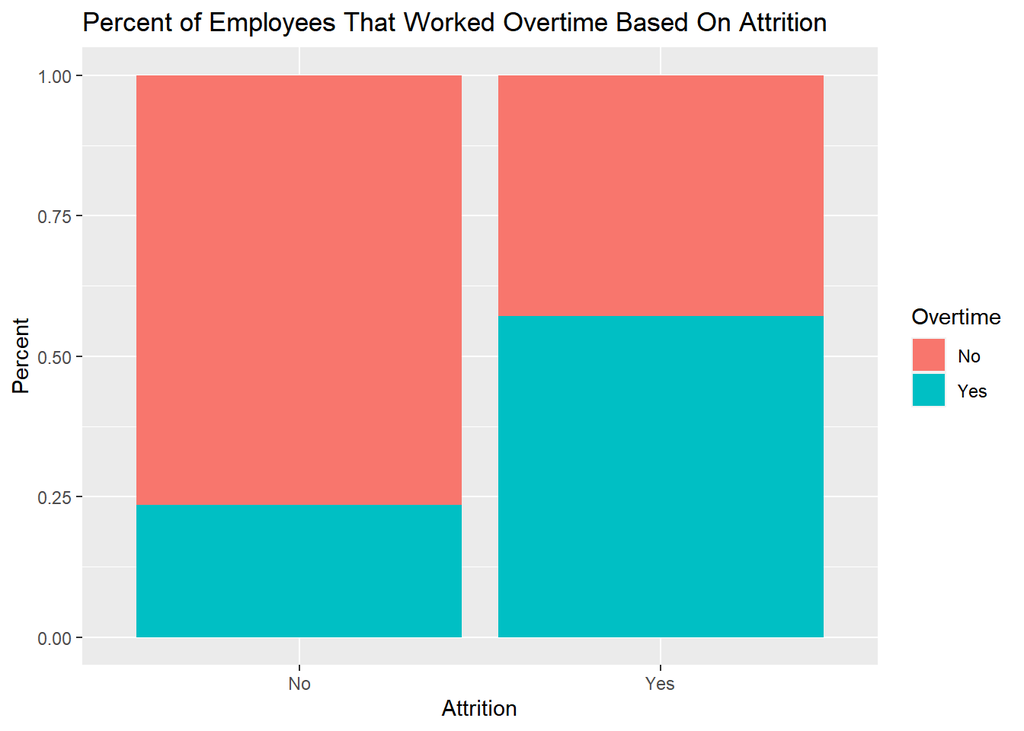

```r
#Overtime barplot
CS2%>%ggplot(aes(x=Attrition,fill=OverTime))+
  geom_bar(position='fill')+
  labs(title="Percent of Employees That Worked Overtime Based On Attrition",
       y="Percent")+
  scale_fill_discrete(name="Overtime")
```

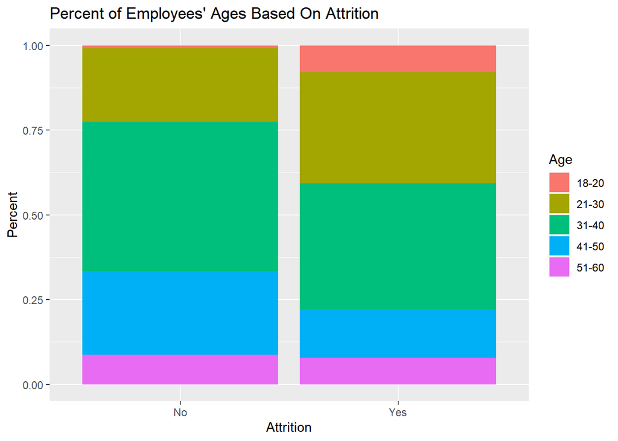

```r
#Age barplot 1
CS2%>%mutate(agefac=cut(Age,breaks=c(10,20,30,40,50,60)))%>%
  ggplot(aes(x=Attrition,fill=agefac))+
  geom_bar(position='fill')+
  labs(title="Percent of Employees' Ages Based On Attrition",
       y="Percent")+
  scale_fill_discrete(name="Age",labels=c("18-20","21-30","31-40","41-50","51-60"))
```

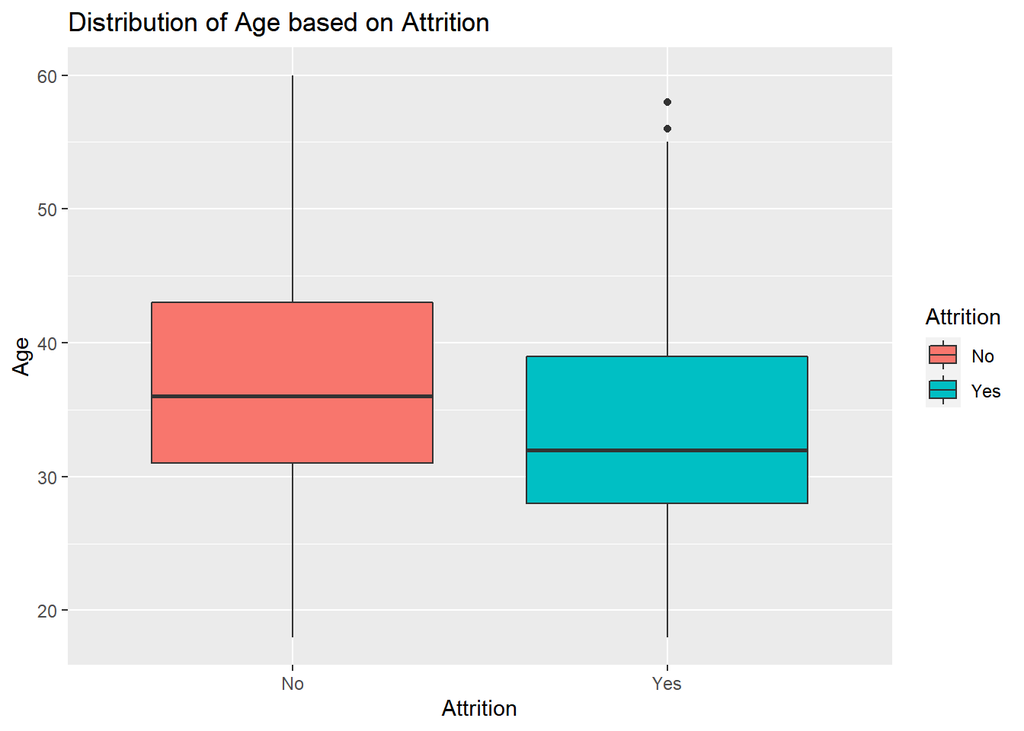

```r
#Age barplot 2
CS2%>%ggplot(aes(x=Attrition,y=Age,fill=Attrition))+
  geom_boxplot()+
  labs(title='Distribution of Age based on Attrition',
       x='Attrition',
       y='Age')
```

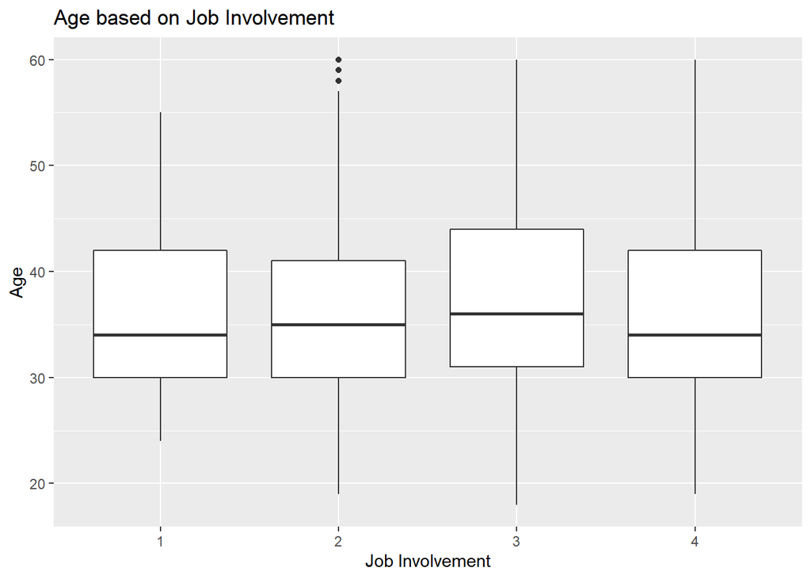

```r
#Job Involvement vs Age barplot
CS2%>%ggplot(aes(x=factor(JobInvolvement),y=Age))+
  geom_boxplot()+
  labs(title="Age based on Job Involvement",
      x="Job Involvement")
```

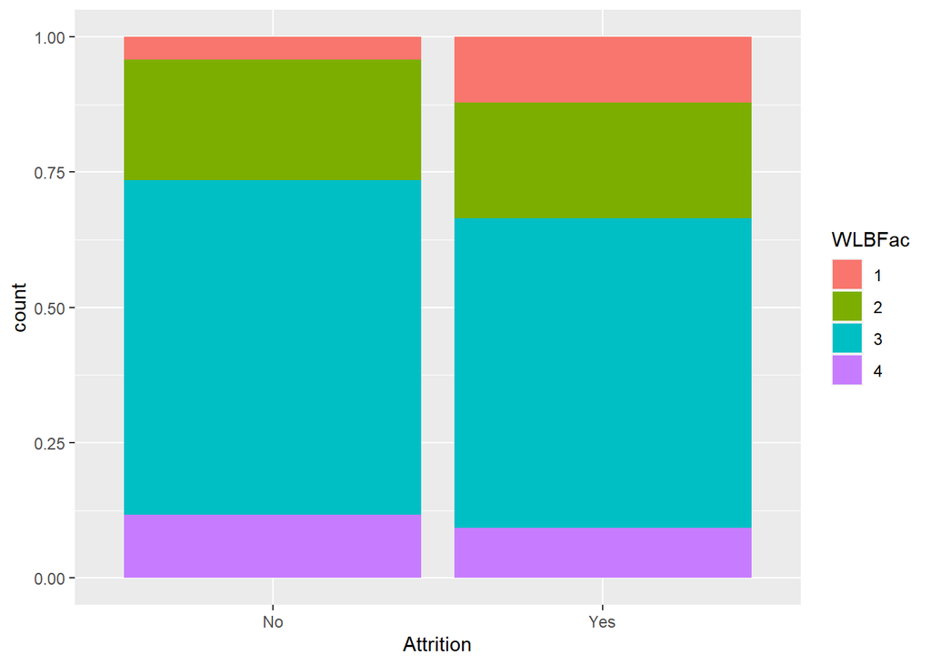

```r
#WLB barplot
CS2%>%mutate(WLBFac=as.factor(WorkLifeBalance))%>%ggplot(aes(x=Attrition,fill=WLBFac))+
  geom_bar(position='fill')
```

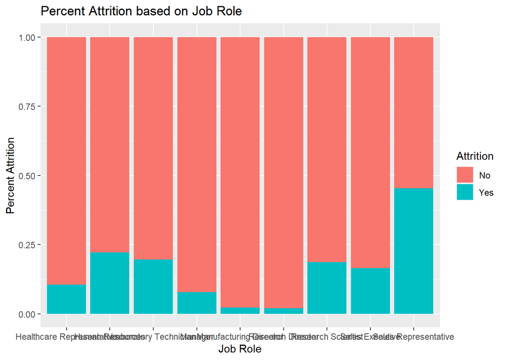

```r
#JobRole barplot
CS2%>%ggplot(aes(x=JobRole,fill=Attrition))+
  geom_bar(position='fill')+
  labs(title='Percent Attrition based on Job Role',
       x='Job Role',
       y='Percent Attrition')
```

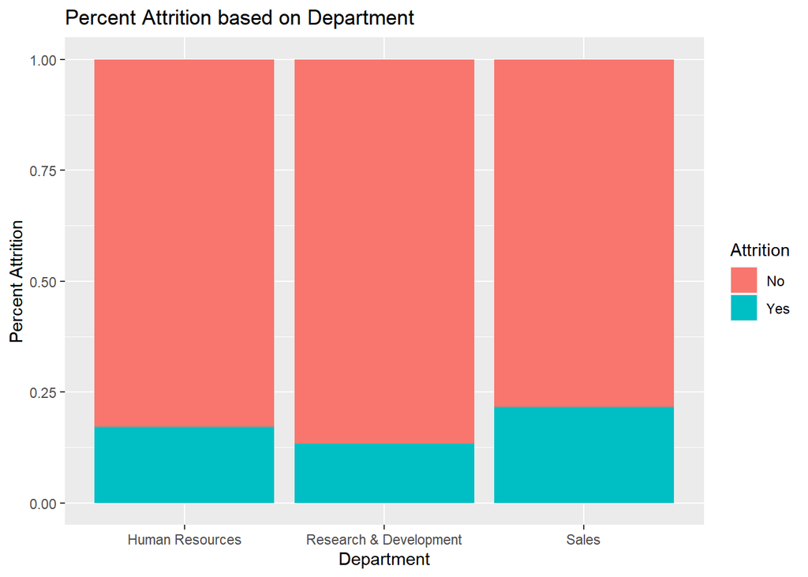

```r
#Department barplot
CS2%>%ggplot(aes(x=Department,fill=Attrition))+
  geom_bar(position='fill')+
  labs(title='Percent Attrition based on Department',
       x='Department',
       y='Percent Attrition')
```